# Causal Inference

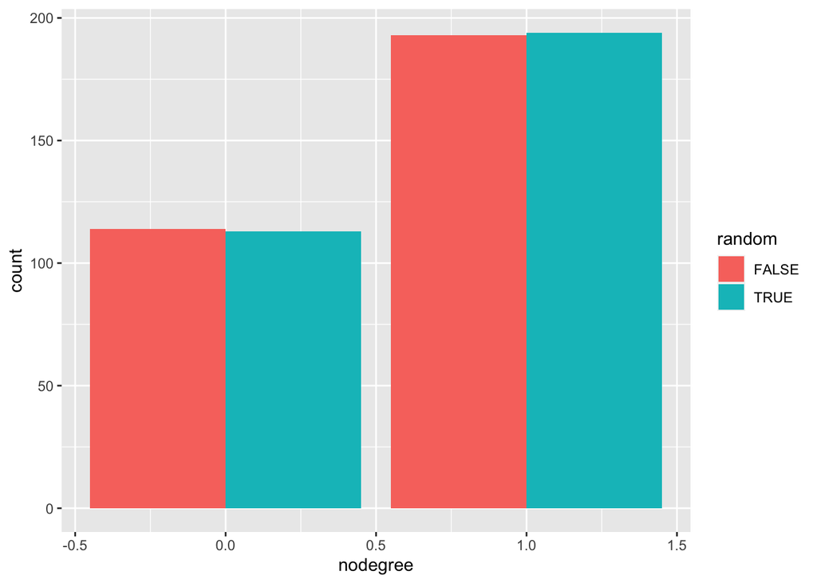

```r
ggplot(lalonde, aes(x=nodegree, fill=random)) + geom_bar(position = 'dodge')
```

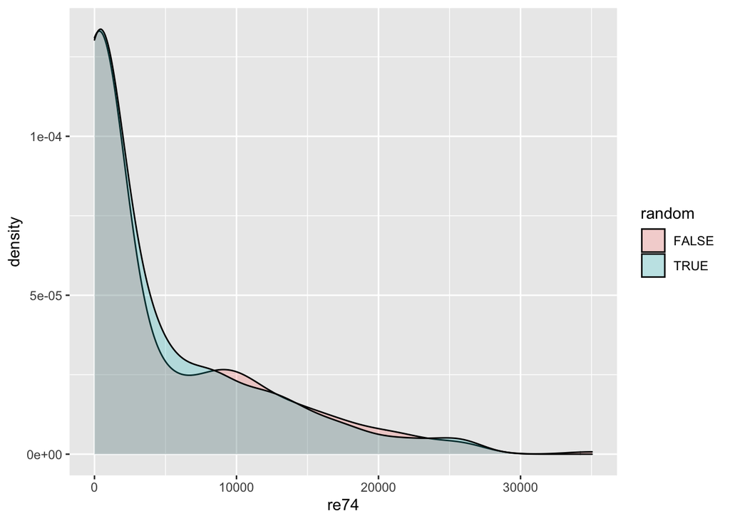

```r
ggplot(lalonde, aes(x=re74, fill=random)) +  geom_density(alpha=0.25)
```

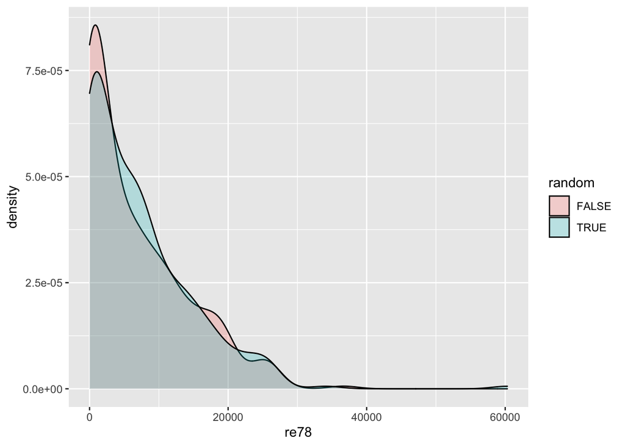

```r
ggplot(lalonde, aes(x=re78, fill=random)) +  geom_density(alpha=0.25)
```

Questions:

What type of bias does causal inference attempt to eliminate? (select all that apply)

- A. Collider bias
- B. Confounder bias
- C. Sampling bias
- D. Small sample bias
- E. Missing data bias

$$\\[0.5in]$$

Randomizing treatments ensures there is no (select all that apply)

- A. Collider bias
- B. Confounder bias
- C. Sampling bias
- D. Small sample bias
- E. Missing data bias

$$\\[0.5in]$$
Average treatment effect (ATE) quantifies what? (text/conversation)

$$\\[0.5in]$$

If $Y$ is the outcome and $A$ the treatment, how can one interpret $E[Y^1 | A=0]$?

- A. Expected value of $Y$ given no treatment
- B. Expected value of $Y$ given treatment
- C. Expected value of $Y$ if given treatment
- D. Expected value of $Y$ if given treatment rather than no treatment

$$\\[0.5in]$$

A UM research wants to understand the impact of a low-calorie vs a low-fat/low-carb diet on weight loss among UM students.

If she advertises enrollment for her study among UM athletes and follows each participant, collecting diet information and weight over time, what are possible sources of statistical association between diet and weight loss in her data? (select all that apply)

- A. Sampling
- B. Causation
- C. Confounding
- D. Noise
- E. Outside influences on weight

$$\\[0.5in]$$

If she advertises enrollment for her study among UM athletes, randomizes diet type for each participant, and collects weight over time, what are possible sources of statistical association between diet and weight loss in her data? (select all that apply)

- A. Sampling
- B. Causation
- C. Confounding
- D. Noise
- E. Outside influences on weight

$$\\[0.5in]$$
Given that there is confounding, how can we stop remove its bias from our parameter estimate? (select all that apply)

- A. If linear, control for confounders in GLM
- B. Use random forest
- C. Weight sample observations
- D. Randomize treatment
- E. Find instrumental variable

$$\\[0.5in]$$

## Observation weighting when treatment not randomized

- In observational data, the population receiving a treatment is difficult to compare to the other groups because of possible confounding
- In the first example, the treatment and non-treatment populations had different severity levels, so are hard to compare directly

```r
table(df$treatment, df$symptoms)
```

```
##
##                mild severe
##   experimental  136    351
##   placebo       378    135
```

```r
chisq.test(df$treatment, df$symptoms)
```

```
##
##  Pearson's Chi-squared test with Yates' continuity correction
##
## data:  df$treatment and df$symptoms
## X-squared = 207.58, df = 1, p-value < 2.2e-16
```

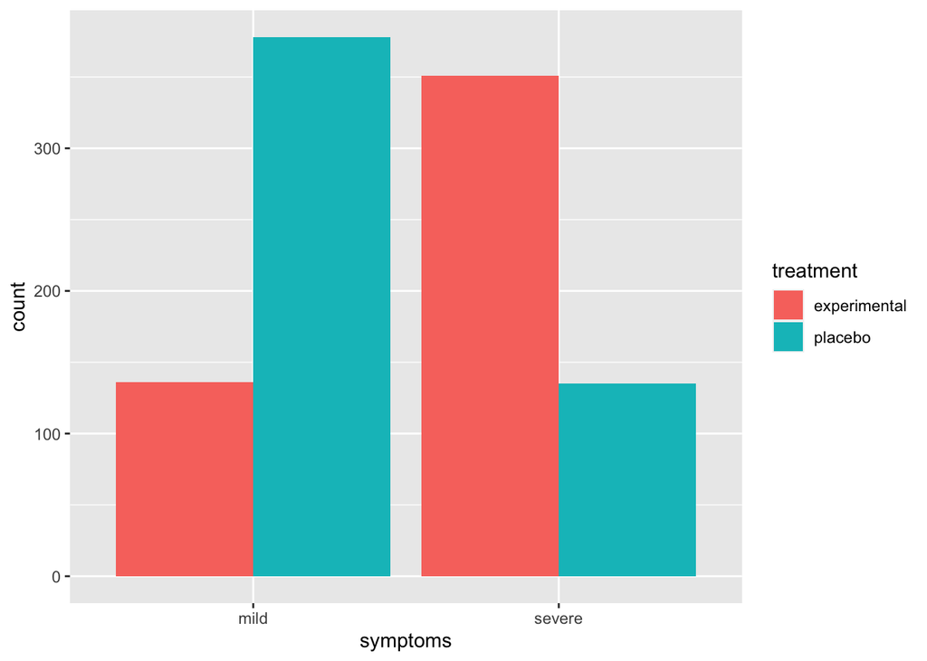

```r
ggplot(df, aes(x=symptoms, fill=treatment)) +  geom_bar(position = 'dodge')
```

- This plot shows that symptoms and treatment are associated
- If severity was used to assign treatment and if symptoms influences outcomes, then there will be confounding
- On the other hand, if symptoms and treatment were independent, then it is not possible for symptoms to confound
- If symptoms and treatment are independent, then the treatment and placebo populations to be generated from the same distribution
- Similarly, for comparison, we want the treatment and placebo populations to be generated from the same distribution
- This blocks any association between confounders and treatment

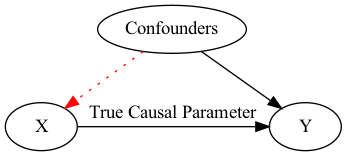

- Propensity scores (PS) indicate propensity for an observation to be in the the treatment group
- Propensity score are sometimes call inverse probability treatment weights
- If a covariate influences (causes) an observation’s chances of getting treatment, it may confound the result
- Question: To be a confounder, what must also happen? (text)

$$\\[0.5in]$$

- PS use (observed) variables to weight observations by calculating on their probability of receiving treatment:
  $$\text{PS}_i = \frac{1}{P(A=1 | C =
  x_i)}$$
- Question: If a variable is unobserved (not in the data), can it still confound?
  - A. Yes
  - B. No
  - C. Not sure

$$\\[0.5in]$$

- PS tries to make the populations look as if treatment were randomized
- In standard regression, each observation contributes that same weight to the parameter estimates
- PS makes it so that each observation contributes a weight which is inversely proportional to its probability of treatment
- Question: Which plot is more likely to use inverse probability treatment weights? (choose A or B)

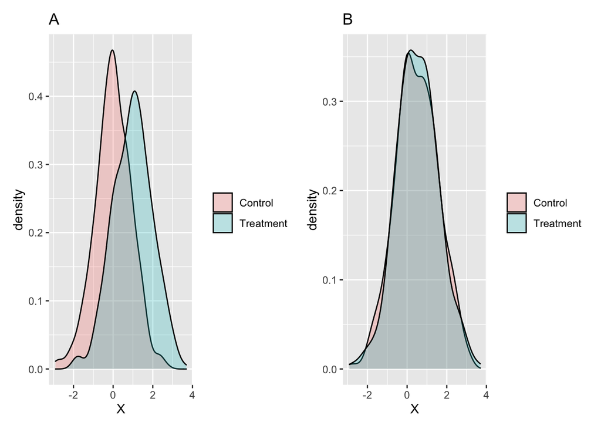

$$\\[0.5in]$$

- Another way to think about inverse probability weighting is **balancing** variables so that all variable distributions look similar in treatment groups after weighting
- Side note: Sometimes people are matched on covariates.
- What is a possible draw back of matching? (conversation)

$$\\[0.5in]$$

### Propensity Score Method

Two-Steps:

1. Fit propensity scores for treatment ($A$) using pre-treatment covariates
2. Use propensity score to estimate ATE (average treatment effect) of $A$ on $Y$

Assumptions:

1. Sufficient overlap: For all $i$
   $$0 <
   P(A=1|C=x_i) < 1$$
2. No unknown confounders: $A \perp \!\!\! \perp Y^t | X$ for $t=0,1$

Probability of Treatment: For each observation, $i$, let
$$p_i =
P(A=1|C=x_i) = P(i \text{ gets treatment}|x_i)$$

the associated weight is
$$w_i =
\begin{cases}
\frac{1}{p_i} & \text{when }A=1 \\
\frac{1}{1-p_i} & \text{when }A=0
\end{cases}$$

Propensity score Theorem
$$(Y^0,Y^1) \perp
A | X \Rightarrow (Y^0, Y^1) \perp A | w(X)$$

- Note: This is saying that getting treatment or not is independent of what the response would have been in a counterfactual setting
- Once the weights are estimates, ATE for a binary treatment is estimated as
  $$\widehat{\text{ATE}} =
  \frac{\sum_{i=1}^n A_iY_iw_i}{\sum_{i=1}^n A_iw_i} -\frac{\sum_{i=1}^n
  (1-A_i)Y_iw_i}{\sum_{i=1}^n (1-A_i)w_i}$$
- Why not use regression to control for confounders [McCaffrey et all 2013](https://onlinelibrary.wiley.com/doi/pdf/10.1002/sim.5753?casa_token=-_Iuef6qRG0AAAAA:jACp_crwgA9QTkHCNfDi-4lJuMDbCXkHDocwRzvvnky5S6rPDQ-j-Cn8QtXNvK5eCKz0ziJ5cURXTw):
1. By summarizing all pretreatment variables to a single score, propensity scores are an important dimension reduction tool for evaluating treatment effects. This characteristic of propensity scores is particularly advantageous over standard adjustment methods when there exists a potentially large number of pretreatment covariates.
2. Propensity score methods derive from a formal model for causal inference, the potential outcomes framework, so that causal questions can be well defined and explicitly specified and not conflated with the modeling approach as they are with traditional regression approaches.
3. Propensity score methods do not require modeling the mean for the outcome. This can help avoid bias from misspecification of that model.
4. Propensity score methods avoid extrapolating beyond the observed data unlike parametric regression modeling for outcomes, which extrapolate whenever the treatment and control groups are disparate on pretreatment variables.
5. Propensity score adjustments can be implemented using only the pretreatment covariates and treatment assignments of study participants without any use of the outcomes. This feature of propensity score adjustments is valuable because it eliminates the potential for the choice of model specification for pretreatment variables to be influenced by its impact on the estimated treatment effect.

### Estimating Weights

- There is no one standard method for model selection in the context of estimating propensity scores for IPTW for multiple treatments
- It’s much more common to use non-parametric methods for estimating probabilities
- Note that in this context, we care more about the prediction value than the interpretation of parameter estimates
- Let’s compare logistic regression and generalized boosted models (GBM) to estimate observation weights
- Question: Why might logistic regression be a **bad** choice for estimating weights?
  - A: Not cross-validated
  - B: Assumes $\text{logit}(E[Y|X])$ is a linear function of parameters
  - C: It’s difficult to test many possible interactions
  - D: B and C
  - E: All of the above

$$\\[0.5in]$$

**Logistic Regression**

- This example is for teaching purposes, it is recommended to not use logistic regression for estimating propensity scores

```r
prop.mod <- glm(treat ~ age + educ+  black + hispan + married + nodegree + re74 + re75, data=lalonde, family=binomial())
summary(prop.mod)
```

```
##
## Call:
## glm(formula = treat ~ age + educ + black + hispan + married +
##     nodegree + re74 + re75, family = binomial(), data = lalonde)
##
## Deviance Residuals:
##     Min       1Q   Median       3Q      Max
## -1.7645  -0.4736  -0.2862   0.7508   2.7169
##
## Coefficients:
##               Estimate Std. Error z value Pr(>|z|)
## (Intercept) -4.729e+00  1.017e+00  -4.649 3.33e-06 ***
## age          1.578e-02  1.358e-02   1.162  0.24521
## educ         1.613e-01  6.513e-02   2.477  0.01325 *
## black        3.065e+00  2.865e-01  10.699  < 2e-16 ***
## hispan       9.836e-01  4.257e-01   2.311  0.02084 *
## married     -8.321e-01  2.903e-01  -2.866  0.00415 **
## nodegree     7.073e-01  3.377e-01   2.095  0.03620 *
## re74        -7.178e-05  2.875e-05  -2.497  0.01253 *
## re75         5.345e-05  4.635e-05   1.153  0.24884
## ---
## Signif. codes:  0 '***' 0.001 '**' 0.01 '*' 0.05 '.' 0.1 ' ' 1
##
## (Dispersion parameter for binomial family taken to be 1)
##
##     Null deviance: 751.49  on 613  degrees of freedom
## Residual deviance: 487.84  on 605  degrees of freedom
## AIC: 505.84
##
## Number of Fisher Scoring iterations: 5
```

```r
treat_prop_logistic <- predict(prop.mod, newdata = lalonde[,-1], type = 'response')
lalonde$logistic_prob <- treat_prop_logistic
lalonde$logistic_weight <- ifelse(lalonde$treat, 1/(1-treat_prop_logistic), 1/treat_prop_logistic)
head(lalonde)
```

```
##   treat age educ black hispan married nodegree re74 re75       re78 random
## 1  TRUE  37   11     1      0       1        1    0    0  9930.0460  FALSE
## 2  TRUE  22    9     0      1       0        1    0    0  3595.8940   TRUE
## 3  TRUE  30   12     1      0       0        0    0    0 24909.4500  FALSE
## 4  TRUE  27   11     1      0       0        1    0    0  7506.1460  FALSE
## 5  TRUE  33    8     1      0       0        1    0    0   289.7899   TRUE
## 6  TRUE  22    9     1      0       0        1    0    0  4056.4940  FALSE
##   logistic_prob logistic_weight
## 1     0.6387699        2.768319
## 2     0.2246342        1.289714
## 3     0.6782439        3.107944
## 4     0.7763241        4.470754
## 5     0.7016387        3.351642
## 6     0.6990699        3.323031
```

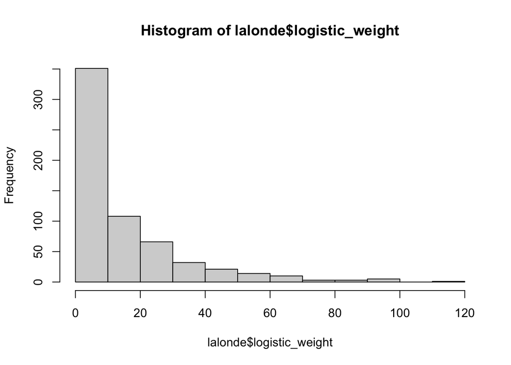

```r
hist(lalonde$logistic_weight)
```

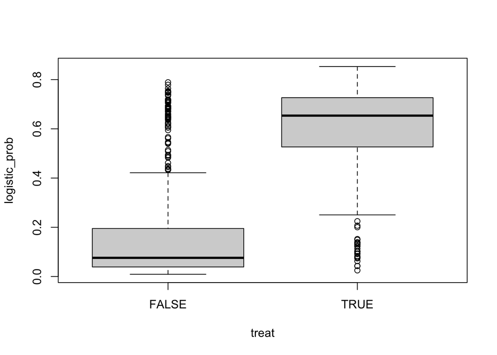

```r
boxplot(logistic_prob ~ treat, data=lalonde)
```

- Assessing covariate balance after weighting
  $$PSB_k = \frac{| \bar X_{k1} - \bar
  X_{k0}|}{\widehat \sigma_k}$$
  where
  $$\bar X_{kt} = \frac{\sum_{i=1}^n I(A=t) X_{ki}
  w_i }{ \sum_{i=1}^n I(A=t) w_i}$$

**Boosting**

- A problem with logistic regression for estimating weights is that can be challenging to get a good model fit
- Boosting makes this a lot easier and automatic
- We already talked about AdaBoost and a little about general boosting

For a reference, in AdaBoost

- each lazy learner is fitted to the data with weights that depend on the last model’s performance
- all of the lazy learners are scored depending on their performance

For general boosting

- Observations are *not* weighted
- We use learners (models) like regression or trees that are more complex than lazy learner
- Similar to AdaBoost, we must choose the number of sequential learner to use, $M$
- Each learner tries to predict the *error* of the previous model
- Error: in the literature, the error is the negative gradient of the loss function with respect to the model evaluated at an observation:
  $$-\frac{\partial L(y_i,f(x_i))}{\partial
  f(x_i)}$$
- For a continuous outcomes, this is $y_i-f(x_i)$ for continuous outcomes where $f$ is a continuous learner
- For a binary outcomes, this is $I(y_i=1)-p(x_i)$ where $p$ is a learner like logistic regression model or decision tree
- For categorical outcomes, this is $I(y_i=\text{Category }k)-p_k(x_i)$ where $p_k$ is models the probability of category $k$
- Learning rate: to avoid over fitting, we reduce the contribution of each learner by $0<\nu<1$
- Trees are the most common learner to use for boosting, usually with between 8 and 32 terminal leaves

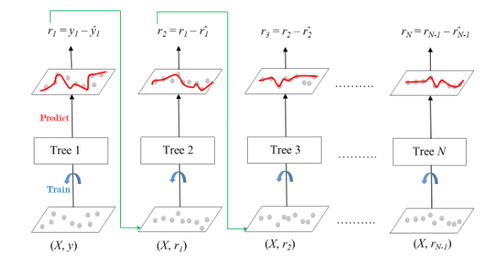

Image from geeksforgeeks

**Gradient Tree Boosting Algorithm from ESL**

1. Initialize $f_0(x)=\arg\min_\gamma \sum_{i=1}^n L(y_i,\gamma)$
2. For $m=1$ to $M$:
   1. For $i=1,\dots,n$ compute the error
      $$r_{im}=-\left[\frac{\partial
      L(y_i,f(x_i))}{\partial f(x_i)}\right]_{f=f_{m-1}}$$
   2. Fit a regression tree to the errors, $r_{im}$ with terminal regions $R_{jm}$ where $j=1,\dots, J_m$
   3. For $j=1,\dots, J_m$ compute
      $$\gamma_{jm}=\arg\min_\gamma \sum_{x_i\in
      R_{jm}} L(y_i,f_{m-1}(x_i)+\gamma)$$
   4. Update $f_m(x)=f_{m-1}(x)+\nu\sum_{j=1}^{J_m} \gamma_{jm}I(x\in R_{jm})$
3. Output $\hat f(x)=f_M(x)$

**Generalized Boosting for Propensity Scores**

```r
boosted.mod <- ps(treat ~ age + educ + black + hispan + married + nodegree + re74 + re75,
                  data=lalonde,
                  estimand = "ATE",
                  n.trees = 5000,
                  interaction.depth=2,
                  perm.test.iters=0,
                  verbose=FALSE,
                  stop.method = c("es.mean"))
summary(boosted.mod)
```

```
##             n.treat n.ctrl ess.treat ess.ctrl    max.es   mean.es    max.ks
## unw             185    429 185.00000 429.0000 1.3085999 0.4432341 0.6404460
## es.mean.ATE     185    429  60.12492 193.2837 0.5527156 0.1873184 0.2705063
##             max.ks.p   mean.ks iter
## unw               NA 0.2702451   NA
## es.mean.ATE       NA 0.1168750 2488
```

```r
summary(boosted.mod$gbm.obj,
        n.trees=boosted.mod$desc$es.mean.ATE$n.trees,
        plot=FALSE)
```

```
##               var     rel.inf
## black       black 56.02950248
## re74         re74 16.57601323
## age           age 16.48551967
## re75         re75  4.22031848
## educ         educ  3.17248606
## married   married  2.97585135
## nodegree nodegree  0.44543160
## hispan     hispan  0.09487713
```

```r
lalonde$boosted <- get.weights(boosted.mod)
```

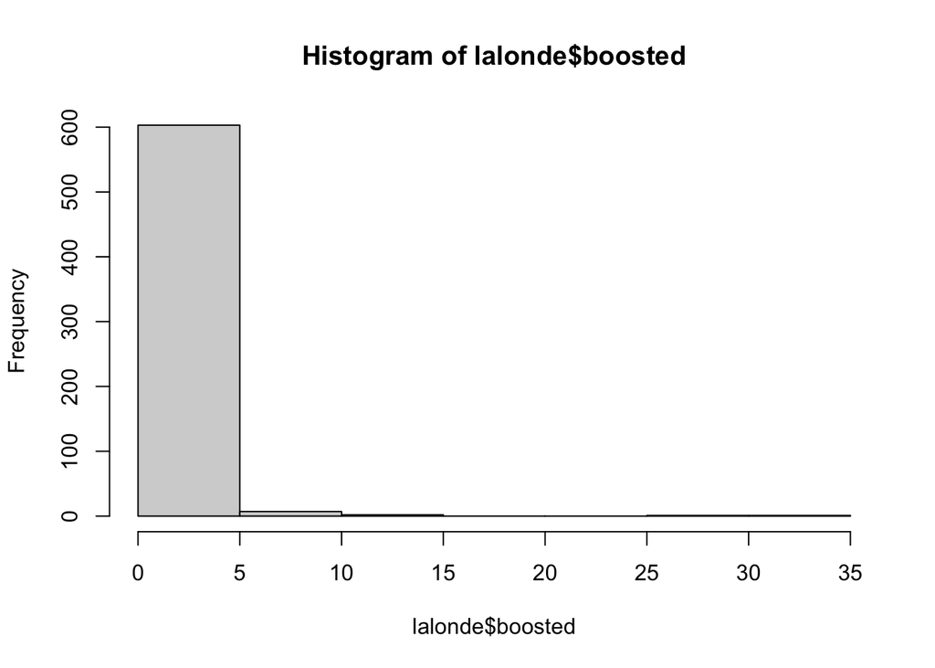

```r
hist(lalonde$boosted)
```

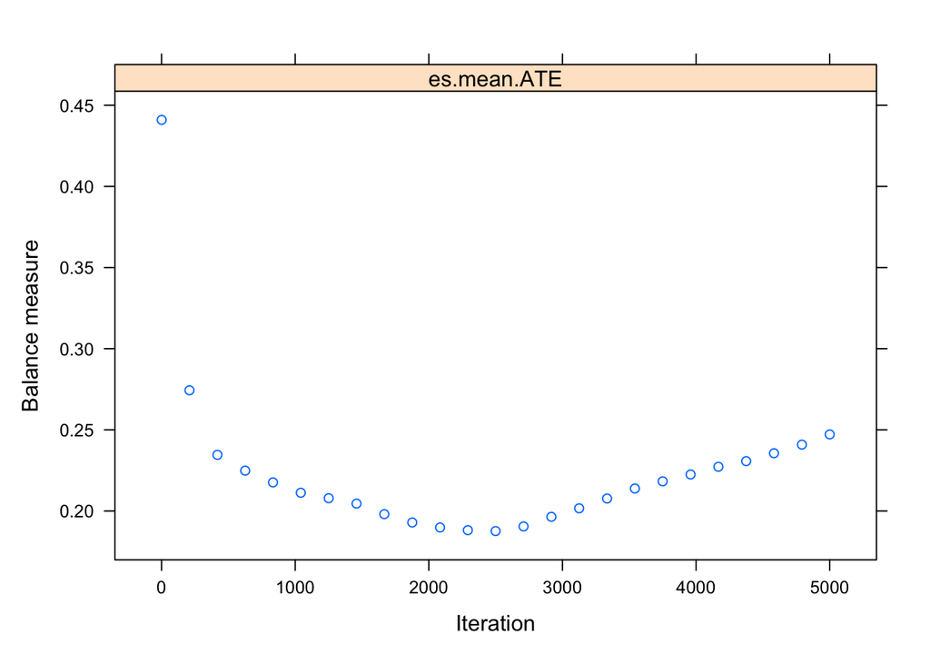

```r
plot(boosted.mod)
```

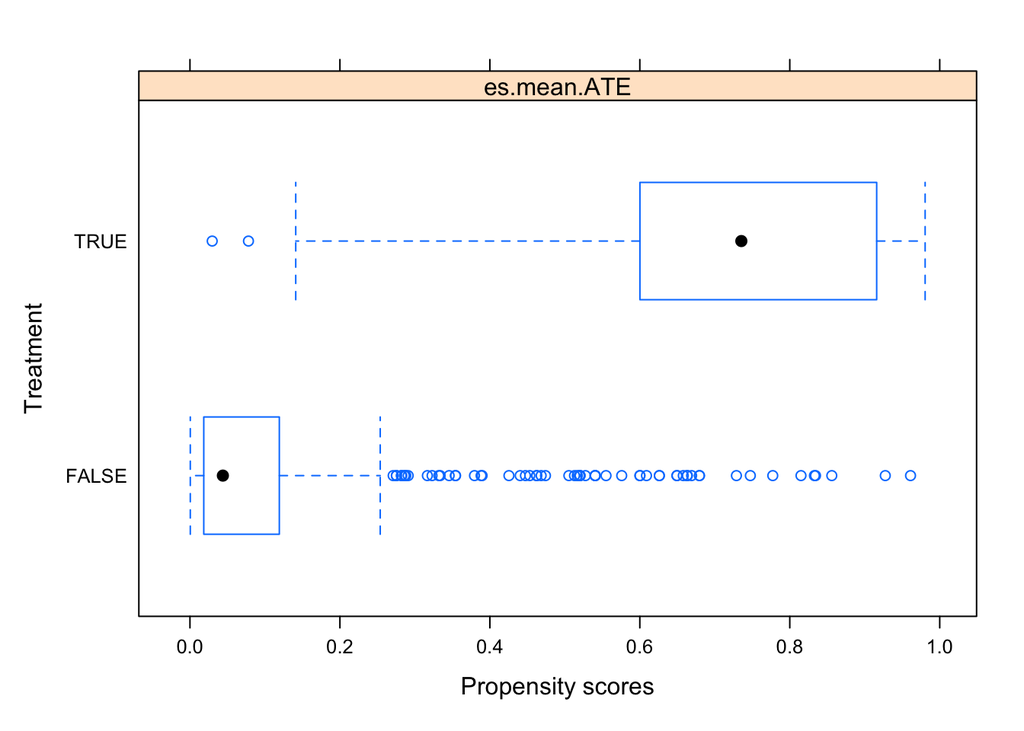

```r
plot(boosted.mod, plots=2)
```

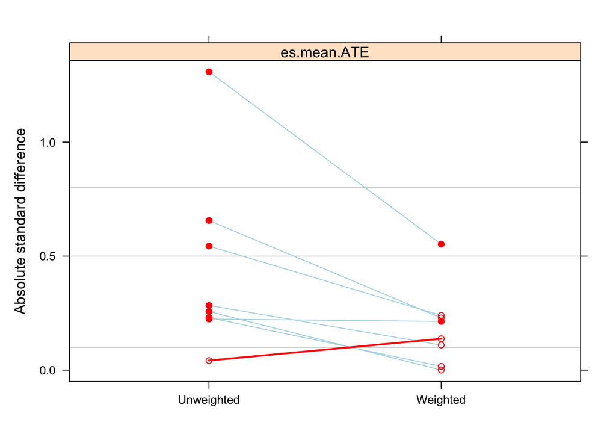

```r
plot(boosted.mod, plots=3)
```

```r
bal.table(boosted.mod)
```

```
## $unw
##             tx.mn    tx.sd    ct.mn    ct.sd std.eff.sz   stat     p    ks
## age        25.816    7.155   28.030   10.787     -0.224 -2.994 0.003 0.158
## educ       10.346    2.011   10.235    2.855      0.042  0.547 0.584 0.111
## black       0.843    0.365    0.203    0.403      1.309 19.371 0.000 0.640
## hispan      0.059    0.237    0.142    0.350     -0.257 -3.413 0.001 0.083
## married     0.189    0.393    0.513    0.500     -0.656 -8.607 0.000 0.324
## nodegree    0.708    0.456    0.597    0.491      0.231  2.716 0.007 0.111
## re74     2095.574 4886.620 5619.237 6788.751     -0.544 -7.254 0.000 0.447
## re75     1532.055 3219.251 2466.484 3291.996     -0.284 -3.282 0.001 0.288
##          ks.pval
## age        0.003
## educ       0.081
## black      0.000
## hispan     0.339
## married    0.000
## nodegree   0.081
## re74       0.000
## re75       0.000
##
## $es.mean.ATE
##             tx.mn    tx.sd    ct.mn    ct.sd std.eff.sz   stat     p    ks
## age        25.369    7.050   27.478   10.057     -0.213 -2.732 0.006 0.135
## educ       10.679    2.035   10.318    2.682      0.137  1.173 0.241 0.090
## black       0.634    0.483    0.364    0.482      0.553  3.080 0.002 0.271
## hispan      0.117    0.323    0.117    0.322      0.000  0.003 0.998 0.000
## married     0.317    0.467    0.430    0.496     -0.229 -1.318 0.188 0.113
## nodegree    0.593    0.493    0.601    0.490     -0.016 -0.099 0.921 0.008
## re74     3034.535 5240.245 4587.694 6420.822     -0.240 -1.874 0.061 0.168
## re75     1784.285 3374.853 2145.958 3190.482     -0.110 -0.940 0.348 0.151
##          ks.pval
## age        0.377
## educ       0.852
## black      0.002
## hispan     1.000
## married    0.604
## nodegree   1.000
## re74       0.152
## re75       0.243
```

## Estimating Average Treatment Effect (ATE)

- Want $E[Y^1] - E[Y^0]$
- Treatment population mean estimate for $t=0,1$:
  $$\widehat\mu_t = \frac{\sum_{i=1}^n I(T_i=t) Y_i
  w_i(t)}{\sum_{i=1}^n I(T_i=t) w_i(t)}$$
- Estimate $E[Y^1] - E[Y^0]$ as
  $$\widehat{\text{ATE}} =
  \widehat\mu_1-\widehat\mu_0$$
- We can use a weighted *t-test* to evaluate $\widehat{\text{ATE}}$
- McCaffery et all suggests using `svyglm` which achieves the same goal

```r
library(survey)
design <- svydesign(ids=~1, weights=~boosted, data=lalonde)
glm1 <- svyglm(re78 ~ treat, design=design)
summary(glm1)
```

```
##
## Call:
## svyglm(formula = re78 ~ treat, design = design)
##
## Survey design:
## svydesign(ids = ~1, weights = ~boosted, data = lalonde)
##
## Coefficients:
##             Estimate Std. Error t value Pr(>|t|)
## (Intercept)   6646.9      388.3  17.118   <2e-16 ***
## treatTRUE     -720.4      866.5  -0.831    0.406
## ---
## Signif. codes:  0 '***' 0.001 '**' 0.01 '*' 0.05 '.' 0.1 ' ' 1
##
## (Dispersion parameter for gaussian family taken to be 49530170)
##
## Number of Fisher Scoring iterations: 2
```

- This indicates that there is no causal effect from being in the work program vs not
- What would we have gotten if we would have used linear regression?

```r
summary(lm(re78 ~ treat + age + educ+  black + hispan + married + nodegree + re74 + re75, data=lalonde))
```

```
##
## Call:
## lm(formula = re78 ~ treat + age + educ + black + hispan + married +
##     nodegree + re74 + re75, data = lalonde)
##
## Residuals:
##    Min     1Q Median     3Q    Max
## -13595  -4894  -1662   3929  54570
##
## Coefficients:
##               Estimate Std. Error t value Pr(>|t|)
## (Intercept)  6.651e+01  2.437e+03   0.027   0.9782
## treatTRUE    1.548e+03  7.813e+02   1.982   0.0480 *
## age          1.298e+01  3.249e+01   0.399   0.6897
## educ         4.039e+02  1.589e+02   2.542   0.0113 *
## black       -1.241e+03  7.688e+02  -1.614   0.1071
## hispan       4.989e+02  9.419e+02   0.530   0.5966
## married      4.066e+02  6.955e+02   0.585   0.5590
## nodegree     2.598e+02  8.474e+02   0.307   0.7593
## re74         2.964e-01  5.827e-02   5.086 4.89e-07 ***
## re75         2.315e-01  1.046e-01   2.213   0.0273 *
## ---
## Signif. codes:  0 '***' 0.001 '**' 0.01 '*' 0.05 '.' 0.1 ' ' 1
##
## Residual standard error: 6948 on 604 degrees of freedom
## Multiple R-squared:  0.1478, Adjusted R-squared:  0.1351
## F-statistic: 11.64 on 9 and 604 DF,  p-value: < 2.2e-16
```

- According to this model, the work program boosted post-treatment earnings by $1548 on average which is borderline significant
- Question: Which model should we trust?
  - A. Propensity score model
  - B. Linear Model
  - C. Other

$$\\[0.5in]$$

#### Unmeasured confounding and mediating variables

- Goal: Quantify causal effect of $A$ on $Y$
- Below: Let $A$ be the treatment, $Y$ the outcome, $X$ measured confounders, $W$ non-confounding variables, $U$ unmeasured confounders

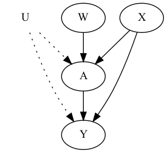

- Question: If there are variables like $U$ (unmeasured confounders), is it possible to use propensity score to determine the causal effect of $A$ on $Y$?
  - A. Yes
  - B. No
  - C. Not sure

$$\\[0.5in]$$

- Question: Assume there are no unmeasured confounders, will using $W$ and $X$ to estimate propensity scores give an accurate causal estimate?
  - A. Yes
  - B. No
  - C. Not sure

$$\\[0.5in]$$

- Question: Assume there are no unmeasured confounders, will only using $X$ to estimate propensity scores give an accurate causal estimate?
  - A. Yes
  - B. No
  - C. Not sure

$$\\[0.5in]$$

- If there are unmeasured confounders, propensity score methods will not give accurate causal estimates for the effect of treatment on outcome
- Including non-confounding, pre-treatment variables in the propensity score analysis, does not bias causal estimates for the effect of treatment on outcome
- Below: Let $A$ be the treatment, $Y$ the outcome, $X$ measured confounders, $W$ non-confounding variables, $M$ mediating variables

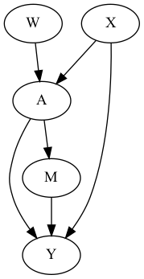

- Question: Will using $W$, $X$, and $M$ to estimate propensity scores give an accurate causal estimate?
  - A. Yes
  - B. No
  - C. Not sure

$$\\[0.5in]$$

- Including a mediating variable in the propensity score analysis will block the causal pathway through that variable
- Generally, we do not want to do this but there may be times where it is warrented

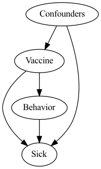

- Example: Vaccines may influence our behavior but also may prevent sickness
- If we want to remove the effect of behavior from the analysis, we can control for it (include it in our propensity score analysis)

### Causal Inference Models Using Instrumental Variables

- Consider the following Bayesian network where the numbers indicate linear parameters, for example $A = 2 Z + C + \epsilon_A$
- Want to determine the causal effect of $A$ on $Y$

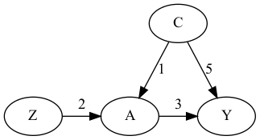

- Question: From the Bayesian network, what is the causal effect of $A$ on $Y$? (numeric answer)

$$\\[0.5in]$$

- Question: Regressing $Y$ on $A$ (in R, $Y \sim A$) would include confounding in the parameter corresponding to $A$
  - A. True
  - B. False
  - C. Not sure

$$\\[0.5in]$$

- Question: Regression $Y$ on $Z$ (in R, $Y\sim Z$) would include confounding in the parameter corresponding $Z$
  - A. True
  - B. False
  - C. Not sure

$$\\[0.5in]$$

- Question: Regression $Y$ on $Z$ (in R, $Y\sim Z$) should have what value for the parameter corresponding $Z$ (numeric)

$$\\[0.5in]$$

- Question: Regression $A$ on $Z$ (in R, $A\sim Z$) should have what value for the parameter corresponding $A$ (numeric)

$$\\[0.5in]$$

```r
set.seed(1234)
n_obs <- 100000

Z <- 400 * rnorm(n_obs)
C <- 500 * rnorm(n_obs)

A <- 2 * Z + 1 * C + rnorm(n_obs)
Y <- 3 * A + 5 * C + rnorm(n_obs)

summary(lm(Y ~ A ))
```

```
##
## Call:
## lm(formula = Y ~ A)
##
## Residuals:
##    Min     1Q Median     3Q    Max
##  -9576  -1427     -3   1426   9368
##
## Coefficients:
##             Estimate Std. Error t value Pr(>|t|)
## (Intercept) 2.496372   6.672603   0.374    0.708
## A           4.398125   0.007078 621.397   <2e-16 ***
## ---
## Signif. codes:  0 '***' 0.001 '**' 0.01 '*' 0.05 '.' 0.1 ' ' 1
##
## Residual standard error: 2110 on 99998 degrees of freedom
## Multiple R-squared:  0.7943, Adjusted R-squared:  0.7943
## F-statistic: 3.861e+05 on 1 and 99998 DF,  p-value: < 2.2e-16
```

```r
summary(lm(Y ~ Z))
```

```
##
## Call:
## lm(formula = Y ~ Z)
##
## Residuals:
##      Min       1Q   Median       3Q      Max
## -18625.1  -2692.4    -18.7   2678.5  16980.1
##
## Coefficients:
##             Estimate Std. Error t value Pr(>|t|)
## (Intercept) 12.81128   12.58789   1.018    0.309
## Z            6.02354    0.03149 191.304   <2e-16 ***
## ---
## Signif. codes:  0 '***' 0.001 '**' 0.01 '*' 0.05 '.' 0.1 ' ' 1
##
## Residual standard error: 3981 on 99998 degrees of freedom
## Multiple R-squared:  0.2679, Adjusted R-squared:  0.2679
## F-statistic: 3.66e+04 on 1 and 99998 DF,  p-value: < 2.2e-16
```

```r
summary(lm(A ~ Z))
```

```
##
## Call:
## lm(formula = A ~ Z)
##
## Residuals:
##      Min       1Q   Median       3Q      Max
## -2327.96  -336.31    -2.43   334.94  2122.81
##
## Coefficients:
##             Estimate Std. Error t value Pr(>|t|)
## (Intercept) 1.603158   1.573487   1.019    0.308
## Z           2.002944   0.003936 508.897   <2e-16 ***
## ---
## Signif. codes:  0 '***' 0.001 '**' 0.01 '*' 0.05 '.' 0.1 ' ' 1
##
## Residual standard error: 497.6 on 99998 degrees of freedom
## Multiple R-squared:  0.7214, Adjusted R-squared:  0.7214
## F-statistic: 2.59e+05 on 1 and 99998 DF,  p-value: < 2.2e-16
```

```r
summary(lm(Y ~ Z))$coefficients[2,1]/summary(lm(A ~ Z))$coefficients[2,1]
```

```
## [1] 3.007345
```

#### Instrumental Variables Big Picture

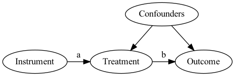

Three steps:

1. Regress Treatment onto Instrument (i.e. treatment as dependent variable) to get $\widehat a$
2. Regress Outcome onto Instrument (i.e. outcome as dependent variable) to estimate $\widehat{ab}$
3. Divide $\frac{\widehat{ab}}{\widehat a}$ to get $\widehat b$

Assumptions:

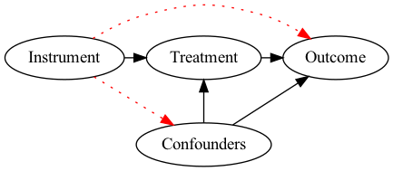

- The instrument does not affect any confounders
- The instrument only affects the outcome through the treatment
- Linearity

#### Minimum wage: Causal Inference and Economics

- Minimum wage is the legal minimum that an employer can pay a worker
- This topic has a contentious history
- The US established a minimum wage during the Great Depression
- But, the federal minimum wage is not tied to inflation, so the actual value of minimum wage decreases over time if not increased by politicians

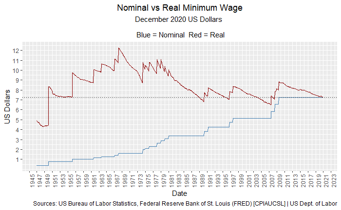

Image from medium.com

- In 1992, 79% of economists responded that having a minimum wage increases unemployment among young and low-skilled workers in a survey of the American Economics Association
- Using the classical supply and demand model, the idea driving this reasoning was that if the price of labor is increased, then the employers will buy less labor, resulting in fewer jobs
- On the other hand, paying employees meager wages while making considerable profit can seem like exploitation
- Does this classical model accurately describe the minimum wage and number of jobs dynamic?
- Just like any model, the supply and demand model requires assumptions
- Further, consider factories vs restaurants:
  - Factories face international competition to keep prices low and can more easily automate jobs
  - Restaurant face local competition and cannot easily automate jobs
- In 1992, New Jersey raised its minimum wage from $4.25/hr to $5.05/hr while Pennsylvania kept its minimum wage at $4.25/hr
- David Card and Alan Krueger at Princeton University used this opportunity to study employment at fast-food restaurants in both states before the April increase and again several months later
- The increase in the wage floor did not lead to jobs being lost in New Jersey; employment in the restaurants they looked at went up
- Results in this [paper](https://www.nber.org/system/files/working_papers/w4509/w4509.pdf)
- Some economists (46%) now think that some labor markets are better characterized by a monopsony market structure: one dominant buyer purchases from many sellers, and so is able to lower prices (wages)
- By increases wages, more people may have been willing to work, at a higher wage
- A following study in 2017, looking at aggregate employment data on average hours and earnings found that increasing the minimum wage in Seattle to $15 led to reducing worker hours and subsequently pay
- Another study in 2018 in Seattle looking at tax data found that after the increase, workers gained earnings on a weekly basis but only because they worked more jobs
- These studies show the impact that data can have on policy
- This material was taken from this [article](https://www.economist.com/schools-brief/2020/08/15/what-harm-do-minimum-wages-do)

#### Earnings after moving

- Using natural randomization: In 1973 the Eldfell volcano in Iceland on the island of Heimaey erupted, destroying about 400 homes.
- The Icelandic government compensated those who lost their homes, many never returned.
- An [economics paper](https://www.nber.org/papers/w22392.pdf) showed that, among people less than 25 years old at the time of the eruption, those who had moved averaged four more years of schooling and earnings $27,000 greater per year than those from families who had kept their home.
- Because those who lost their homes was naturally randomized, this paper used instrumental variables
- The treatment was moving away and the outcome was later earnings
- Losing home $\rightarrow$ moving away $\rightarrow$ later earnings
- Instrument $\rightarrow$ Treatment $\rightarrow$ Effect
- Instrument can only influence effect through treatment (no direct arrow from instrument to effect)
- We are not going to focus on instrumental variables analysis here
- Used when there is a natural experiment

### Regression with knowledge of causal structure

$$\\[0.5in]$$

$$\\[0.5in]$$

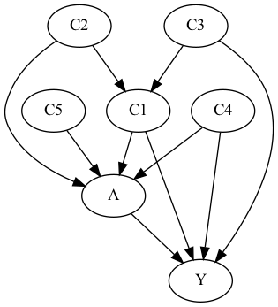

- Now, we want to quantify the causal impact of $A$ on $Y$ without assuming linearity
- Question: Would using $C1, C2, C3, C4, C5$ for propensity score weighting accurately quantify the effect of $A$ on $Y$?
  - A. Yes
  - B. No

$$\\[0.5in]$$

- Question: Would using $C1, C2, C3, C4$ for propensity score weighting accurately quantify the effect of $A$ on $Y$?
  - A. Yes
  - B. No

$$\\[0.5in]$$

- Question: Would using $C1, C4$ for propensity score weighting accurately quantify the effect of $A$ on $Y$?
  - A. Yes
  - B. No

$$\\[0.5in]$$

- Question: Would using $C1, C2, C4$ for propensity score weighting accurately quantify the effect of $A$ on $Y$?
  - A. Yes
  - B. No

$$\\[0.5in]$$
- Question: Would using $C5$ as an instrumental variable accurately quantify the effect of $A$ on $Y$?

- A. Yes
- B. No

$$\\[0.5in]$$
- Question: If we want to predict $Y$, which variables do we **not** need?

- A. $C1$
- B. $C2$
- C. $C3$
- D. $C4$
- E. $C5$

$$\\[0.5in]$$

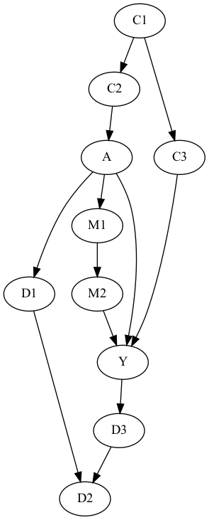

- We want to isolate the causal effect of A on Y
- Would conditioning on $C2$ only accurately quantify the causal effect of A on Y?
  - A. Yes
  - B. No

$$\\[0.5in]$$

- Would conditioning on $C3$ accurately quantify the causal effect of A on Y?
  - A. Yes
  - B. No

$$\\[0.5in]$$

- Would conditioning on $C1$ and $D1$ accurately quantify the causal effect of A on Y?
  - A. Yes
  - B. No

$$\\[0.5in]$$

- Would conditioning on $C1$ and $D2$ accurately quantify the causal effect of A on Y?
  - A. Yes
  - B. No

$$\\[0.5in]$$

- Would conditioning on $C1$ and $M2$ accurately quantify the causal effect of A on Y?
  - A. Yes
  - B. No

$$\\[0.5in]$$

## Writing tips

- Intro paragraph:
  - Give the big picture in one sentence. What is the general application field?
  - What is the problem you are attempting to answer?
  - How will you answer it?
  - In one sentence, what did you find?
- Give the baseline characteristics of the data after cleaning
  - How many observations with salient brake down
  - A table is a very efficient way to summarize data:

|  | Total (n) | Treatment (n1) | Control (n2) | p-value |
| --- | --- | --- | --- | --- |
| Covariate 1 | mean (sd) | mean (sd) | mean (sd) | <0.001 |
| Covariate 2 | % | % | % | 0.34 |
| Covariate 3 | median (q1, q3) | median (q1, q3) | median (q1, q3) | 0.02 |

- Present you most important model (or models)
  - Clearly interpret the parameter of interest and its connection to the larger question that is being asked
  - A lot of this material is technical. You’re job is to understand the larger statistical picture and communicate it in an easy to understand way to someone who does not have any background in statistics an who probably does not do math regularly
- Example: how would you describe IPW to a client?
  1. Why do we use IPW in the first place?
  2. What does IPW do?
  3. How does IPW attempt to allow a causal interpretation for ATE?
- Conclusion:
  - Restate what you attempted to answer
  - State any potential limitation
  - Reiterate findings
- Don’t
  - try to explain d-separation or Bayesian networks
  - think of a statistician as your audience
- Do
  - rely on intuition about causation
  - use your understanding of causal modeling to answer the question